# Lecture 12 - Ensemble Modeling

ANLY 530- Principles and Applications of Machine Learning

# Outline

- What is Ensemble Modeling?
- Ensemble Modeling in R and Python

# What is Ensemble Modeling?

Ensemble modeling is the process of running two or more related but different analytical models and then synthesizing the results into a single score or spread in order to improve the accuracy of predictive analytics and data mining applications.

# Ensemble Modeling in Python

- We will build a regression ensemble and a classification ensemble using `sklearn` in Python.

# Regression Ensemble in Python

- Load the data.
- Lets see if we cannot build a regression ensemble to predict outcome of daily demand of orders.

```python
import pandas as pd
df = pd.read_csv("D:/Roozbeh/My courses/Summer2023/ANLY530/Lecture12- Ensemble Models/data/Daily_Demand_Forecasting_Orders.csv", sep = ';')
df.head()
```

```
##    Week of the month (first week, second, third, fourth or fifth week  ...  Target (Total orders)
## 0                                                  1                   ...                539.577
## 1                                                  1                   ...                224.675
## 2                                                  1                   ...                129.412
## 3                                                  2                   ...                317.120
## 4                                                  2                   ...                210.517
##
## [5 rows x 13 columns]
```

# Split the Data

```python
X = df.drop(columns = ['Target (Total orders)'])
y = df['Target (Total orders)']
from sklearn.model_selection import train_test_split
X_train, X_test, y_train, y_test = train_test_split(X, y, test_size=0.3)
```

# Build the First Model

```python
import numpy as np
from sklearn.linear_model import LinearRegression
lr = LinearRegression()
lr.fit(X_train, y_train)
```

```
## LinearRegression()
```

# Build the Second Model

```python
from sklearn import svm
svm = svm.SVR()
svm.fit(X_train, y_train)
```

```
## SVR()
```

# Build the Third Model

```python
from sklearn import tree
dt = tree.DecisionTreeRegressor()
dt.fit(X_train, y_train)
```

```
## DecisionTreeRegressor()
```

# Check the fit of All Three Models Individually

```python
print('lr: {}'.format(lr.score(X_test, y_test)))
```

```
## lr: 1.0
```

```python
print('svm: {}'.format(svm.score(X_test, y_test)))
```

```
## svm: -0.17410084993818487
```

```python
print('dt: {}'.format(dt.score(X_test, y_test)))
```

```
## dt: 0.6458144819770696
```

# Ensemble the Models

```python
from sklearn.ensemble import VotingRegressor
estimators=[('lr', lr), ('svm', svm), ('dt', dt)]
ensemble = VotingRegressor(estimators)
```

# Train and Test the Ensemble

- You may want to grab some other supporting metrics to compare the ensemble performance to the individual models, but will keep it simple now.

```python
ensemble.fit(X_train, y_train)
```

```
## VotingRegressor(estimators=[('lr', LinearRegression()), ('svm', SVR()),
##                             ('dt', DecisionTreeRegressor())])
```

```python
ensemble.score(X_test, y_test)
```

```
## 0.7705878123505076
```

# Classification Ensemble in Python

```python
import pandas as pd
df = pd.read_csv("D:/Roozbeh/My courses/Summer2023/ANLY530/Lecture12- Ensemble Models/data/diabetes.csv")
df.head()
```

```
##    Pregnancies  Glucose  BloodPressure  ...  DiabetesPedigreeFunction  Age  Outcome
## 0            6      148             72  ...                     0.627   50        1
## 1            1       85             66  ...                     0.351   31        0
## 2            8      183             64  ...                     0.672   32        1
## 3            1       89             66  ...                     0.167   21        0
## 4            0      137             40  ...                     2.288   33        1
##
## [5 rows x 9 columns]
```

# Split the Data

```python
X = df.drop(columns = ['Outcome'])
y = df['Outcome']
from sklearn.model_selection import train_test_split
X_train, X_test, y_train, y_test = train_test_split(X, y, test_size=0.3, stratify=y)
```

# Build the First Model

```python
import numpy as np
from sklearn.model_selection import GridSearchCV
from sklearn.neighbors import KNeighborsClassifier
knn = KNeighborsClassifier()
params_knn = {'n_neighbors': np.arange(1, 25)}
knn_gs = GridSearchCV(knn, params_knn, cv=5)
knn_gs.fit(X_train, y_train)
```

```
## GridSearchCV(cv=5, estimator=KNeighborsClassifier(),
##              param_grid={'n_neighbors': array([ 1,  2,  3,  4,  5,  6,  7,  8,  9, 10, 11, 12, 13, 14, 15, 16, 17,
##        18, 19, 20, 21, 22, 23, 24])})
```

# Store the First Model’s Results

```python
knn_best = knn_gs.best_estimator_
print(knn_gs.best_params_)
```

```
## {'n_neighbors': 9}
```

# Build the Second Model

```python
from sklearn.model_selection import GridSearchCV
from sklearn.ensemble import RandomForestClassifier
rf = RandomForestClassifier()
params_rf = {'n_estimators': [50, 100, 200]}
rf_gs = GridSearchCV(rf, params_rf, cv=5)
rf_gs.fit(X_train, y_train)
```

```
## GridSearchCV(cv=5, estimator=RandomForestClassifier(),
##              param_grid={'n_estimators': [50, 100, 200]})
```

# Store the Second Model’s Results

```python
rf_best = rf_gs.best_estimator_
print(rf_gs.best_params_)
```

```
## {'n_estimators': 200}
```

# Build the Third Model

```python
from sklearn.linear_model import LogisticRegression
log_reg = LogisticRegression()
log_reg.fit(X_train, y_train)
```

```
## LogisticRegression()
##
## STOP: TOTAL NO. of ITERATIONS REACHED LIMIT.
##
## Increase the number of iterations (max_iter) or scale the data as shown in:
##     https://scikit-learn.org/stable/modules/preprocessing.html
## Please also refer to the documentation for alternative solver options:
##     https://scikit-learn.org/stable/modules/linear_model.html#logistic-regression
##   n_iter_i = _check_optimize_result(
```

# Check the Accuracy of All Three Models Individually

```python
print('knn: {}'.format(knn_best.score(X_test, y_test)))
```

```
## knn: 0.7532467532467533
```

```python
print('rf: {}'.format(rf_best.score(X_test, y_test)))
```

```
## rf: 0.7575757575757576
```

```python
print('log_reg: {}'.format(log_reg.score(X_test, y_test)))
```

```
## log_reg: 0.7705627705627706
```

# Ensemble the Models

```python
from sklearn.ensemble import VotingClassifier
estimators=[('knn', knn_best), ('rf', rf_best), ('log_reg', log_reg)]
ensemble = VotingClassifier(estimators, voting='hard')
```

# Train and Test the Ensemble

- You may want to grab some other supporting metrics to compare the ensemble performance to the individual models, but will keep it simple now.

```python
ensemble.fit(X_train, y_train)
```

```
## VotingClassifier(estimators=[('knn', KNeighborsClassifier(n_neighbors=9)),
##                              ('rf', RandomForestClassifier(n_estimators=200)),
##                              ('log_reg', LogisticRegression())])
##
## STOP: TOTAL NO. of ITERATIONS REACHED LIMIT.
##
## Increase the number of iterations (max_iter) or scale the data as shown in:
##     https://scikit-learn.org/stable/modules/preprocessing.html
## Please also refer to the documentation for alternative solver options:
##     https://scikit-learn.org/stable/modules/linear_model.html#logistic-regression
##   n_iter_i = _check_optimize_result(
```

```python
ensemble.score(X_test, y_test)
```

```
## 0.7792207792207793
```

# Ensemble Modeling in R

- We will build a regression ensemble and a classification ensemble using `caret` in R.

```r
library(caret)
library(caretEnsemble)
library(parallel)
library(doParallel)
```

# Regression Ensemble in R

- Load the data.
- Lets see if we cannot build a regression ensemble to predict the number of chicken pox cases in Budapest Hungary.

```r
library(readr)
data <- read_csv("D:/Roozbeh/My courses/Summer2023/ANLY530/Lecture12- Ensemble Models/data/hungary_chickenpox.csv")
data = data.frame(data[,-c(1)])
str(data)
```

```
## 'data.frame':    522 obs. of  20 variables:
##  $ BUDAPEST: num  168 157 96 163 122 174 153 115 119 114 ...
##  $ BARANYA : num  79 60 44 49 78 76 103 74 86 81 ...
##  $ BACS    : num  30 30 31 43 53 77 54 64 57 129 ...
##  $ BEKES   : num  173 92 86 126 87 152 192 174 171 217 ...
##  $ BORSOD  : num  169 200 93 46 103 189 148 140 90 167 ...
##  $ CSONGRAD: num  42 53 30 39 34 26 65 56 65 64 ...
##  $ FEJER   : num  136 51 93 52 95 74 100 111 118 93 ...
##  $ GYOR    : num  120 70 84 114 131 181 118 175 105 154 ...
##  $ HAJDU   : num  162 84 191 107 172 157 129 138 194 119 ...
##  $ HEVES   : num  36 28 51 42 40 44 40 60 60 34 ...
##  $ JASZ    : num  130 80 64 63 61 95 88 112 67 118 ...
##  $ KOMAROM : num  57 50 46 54 49 97 56 70 46 73 ...
##  $ NOGRAD  : num  2 29 4 14 11 26 10 21 12 6 ...
##  $ PEST    : num  178 141 157 107 124 146 119 178 112 130 ...
##  $ SOMOGY  : num  66 48 33 66 63 59 104 70 116 68 ...
##  $ SZABOLCS: num  64 29 33 50 56 54 85 75 76 59 ...
##  $ TOLNA   : num  11 58 24 25 7 27 20 5 22 31 ...
##  $ VAS     : num  29 53 18 21 47 54 32 66 45 85 ...
##  $ VESZPREM: num  87 68 62 43 85 48 153 149 102 96 ...
##  $ ZALA    : num  68 26 44 31 60 60 70 54 42 54 ...
```

# Split the Data

```r
index = createDataPartition(data$BUDAPEST, p =0.80, list = FALSE)
train = data[index,]
valid = data[-index,]
```

# Set the Modeling Parameters

```r
seeds <- vector(mode = "list", length = 51)
for(i in 1:50) seeds[[i]] <- sample.int(1000, 22)
seeds[[51]] <- sample.int(222, 1)
control <- trainControl(method="cv", number=10,
                        allowParallel=TRUE,
                        search="grid",
                        savePredictions = "final",
                        seeds = seeds)
preProc=c(NULL)
no_cores <- detectCores() - 1
```

# Create a Cluster and Set the Models to Train

```r
cl <- makePSOCKcluster(no_cores)
registerDoParallel(cl)
model_list <- caretList(BUDAPEST~.,
                        train,
                        methodList = c('rpart','rf','lm'),
                        continue_on_fail = FALSE,
                        preProcess = preProc,
                        tuneList=NULL,
                        trControl=control
)
stopCluster(cl)
registerDoSEQ()
```

# Compare the Individual Models Trained

```r
results = resamples(model_list)
summary(results)
```

```
##
## Call:
## summary.resamples(object = results)
##
## Models: rpart, rf, lm
## Number of resamples: 10
##
## MAE
##           Min.  1st Qu.   Median     Mean  3rd Qu.     Max. NA's
## rpart 33.66625 37.15808 38.96212 39.54818 43.11939 44.05211    0
## rf    22.36060 26.31853 30.14150 29.47777 32.33743 35.37273    0
## lm    25.57232 28.26422 31.72710 31.57140 33.54424 39.97946    0
##
## RMSE
##           Min.  1st Qu.   Median     Mean  3rd Qu.     Max. NA's
## rpart 43.91588 49.28239 55.13933 54.29386 56.83328 71.06401    0
## rf    28.91817 34.68102 44.72438 42.04516 47.04614 54.93612    0
## lm    31.03757 38.50769 46.31911 43.30989 48.06688 51.36239    0
##
## Rsquared
##            Min.   1st Qu.    Median      Mean   3rd Qu.      Max. NA's
## rpart 0.3498275 0.4763568 0.5057435 0.5015794 0.5494529 0.5812762    0
## rf    0.6130730 0.6580111 0.6892773 0.7039073 0.7479833 0.8129469    0
## lm    0.6247419 0.6450956 0.6658024 0.6884983 0.7247263 0.7914801    0
```

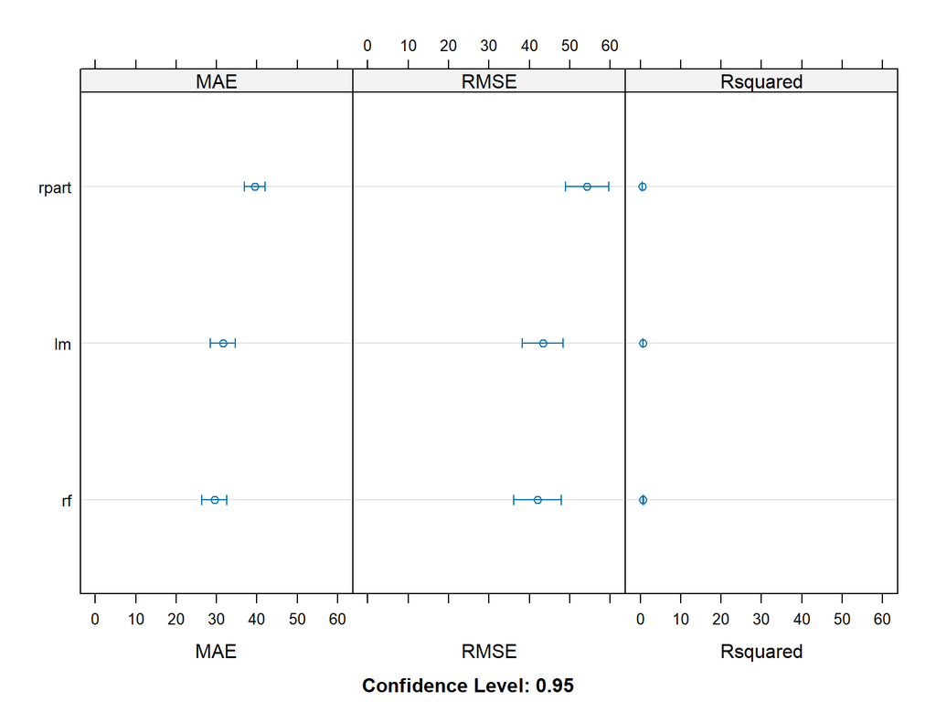

```r
dotplot(results)
```

# Check None of the Models are Highly Correlated

```r
modelCor(results)
```

```
##           rpart        rf        lm
## rpart 1.0000000 0.7233205 0.7005931
## rf    0.7233205 1.0000000 0.9042841
## lm    0.7005931 0.9042841 1.0000000
```

# Ensemble the Models

```r
ensemble <- caretEnsemble(model_list,
                            metric = 'RMSE',
                            trControl = control)
summary(ensemble)
```

```
## The following models were ensembled: rpart, rf, lm
## They were weighted:
## -3.4132 -0.0782 0.7604 0.3541
## The resulting RMSE is: 42.1306
## The fit for each individual model on the RMSE is:
##  method     RMSE   RMSESD
##   rpart 54.29386 7.418722
##      rf 42.04516 8.280600
##      lm 43.30989 7.059127
```

# Visualize the Ensemble

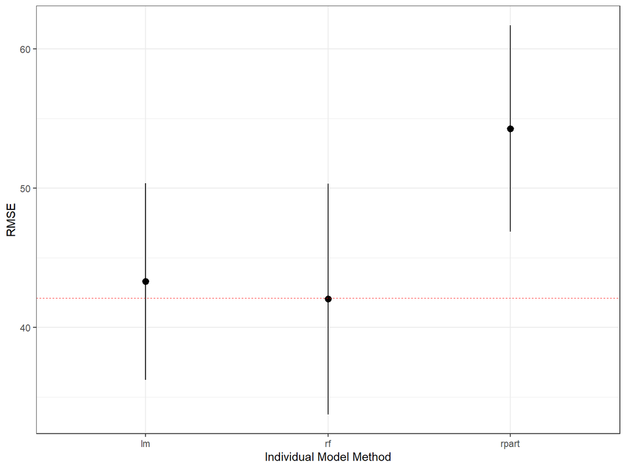

```r
plot(ensemble)
```

# Capture the Prediction

- You may want to grab some other supporting metrics to compare the ensemble performance to the individual models, but will keep it simple now.

```r
data.pred = predict(ensemble, newdata = valid)
postResample(pred = data.pred, obs = valid$BUDAPEST)
```

```
##       RMSE   Rsquared        MAE
## 41.8059760  0.7053044 29.9595757
```

# Classification Ensemble in R

- Load the data.
- Lets see if we cannot build a classification ensemble to predict risk an audit or not in the audit dataset.

```r
data <- read_csv("D:/Roozbeh/My courses/Summer2023/ANLY530/Lecture12- Ensemble Models/data/audit_risk.csv")
data$class = factor(data$Risk, levels = c(0,1), labels = c("No","Yes"))
data = data.frame(na.omit(data[,-c(2,19,21,27)]))
str(data)
```

```
## 'data.frame':    775 obs. of  24 variables:
##  $ Sector_score  : num  3.89 3.89 3.89 3.89 3.89 3.89 3.89 3.89 3.89 3.89 ...
##  $ PARA_A        : num  4.18 0 0.51 0 0 0 1.1 8.5 8.4 3.98 ...
##  $ Score_A       : num  0.6 0.2 0.2 0.2 0.2 0.2 0.4 0.6 0.6 0.6 ...
##  $ Risk_A        : num  2.508 0 0.102 0 0 ...
##  $ PARA_B        : num  2.5 4.83 0.23 10.8 0.08 ...
##  $ Score_B...7   : num  0.2 0.2 0.2 0.6 0.2 0.2 0.4 0.6 0.6 0.2 ...
##  $ Risk_B        : num  0.5 0.966 0.046 6.48 0.016 ...
##  $ TOTAL         : num  6.68 4.83 0.74 10.8 0.08 ...
##  $ numbers       : num  5 5 5 6 5 5 5 5.5 5.5 5 ...
##  $ Score_B...11  : num  0.2 0.2 0.2 0.6 0.2 0.2 0.2 0.4 0.4 0.2 ...
##  $ Risk_C        : num  1 1 1 3.6 1 1 1 2.2 2.2 1 ...
##  $ Money_Value   : num  3.38 0.94 0 11.75 0 ...
##  $ Score_MV      : num  0.2 0.2 0.2 0.6 0.2 0.2 0.6 0.4 0.4 0.2 ...
##  $ Risk_D        : num  0.676 0.188 0 7.05 0 ...
##  $ District_Loss : num  2 2 2 2 2 2 2 2 2 2 ...
##  $ PROB          : num  0.2 0.2 0.2 0.2 0.2 0.2 0.2 0.2 0.2 0.2 ...
##  $ RiSk_E        : num  0.4 0.4 0.4 0.4 0.4 0.4 0.4 0.4 0.4 0.4 ...
##  $ Prob          : num  0.2 0.2 0.2 0.2 0.2 0.2 0.2 0.2 0.2 0.2 ...
##  $ Score         : num  2.4 2 2 4.4 2 2 3.2 4.2 4.2 2.4 ...
##  $ Inherent_Risk : num  8.57 2.55 1.55 17.53 1.42 ...
##  $ CONTROL_RISK  : num  0.4 0.4 0.4 0.4 0.4 0.4 0.4 0.4 0.4 0.4 ...
##  $ Detection_Risk: num  0.5 0.5 0.5 0.5 0.5 0.5 0.5 0.5 0.5 0.5 ...
##  $ Audit_Risk    : num  1.715 0.511 0.31 3.506 0.283 ...
##  $ class         : Factor w/ 2 levels "No","Yes": 2 1 1 2 1 1 2 2 2 1 ...
```

# Split the Data

```r
index = createDataPartition(data[,1], p =0.70, list = FALSE)
train = data[index,]
valid = data[-index,]
```

# Set the Modeling Parameters

```r
seeds <- vector(mode = "list", length = 51)
for(i in 1:50) seeds[[i]] <- sample.int(1000, 22)
seeds[[51]] <- sample.int(222, 1)
control <- trainControl(method="cv", number=10,
                        allowParallel=TRUE,
                        search="grid",
                        savePredictions = "final",
                        classProbs=TRUE,
                        seeds = seeds)
preProc=c(NULL)
```

# Create a Cluster and Set the Models to Train

```r
no_cores <- detectCores() - 1
cl <- makePSOCKcluster(no_cores)
registerDoParallel(cl)
model_list <- caretList(class~.,
                        train,
                        methodList = c('rpart','rf','nb'),
                        continue_on_fail = FALSE,
                        preProcess = preProc,
                        tuneList=NULL,
                        trControl=control
)

stopCluster(cl)
registerDoSEQ()
```

# Compare the Individual Models Trained

```r
results = resamples(model_list)
summary(results)
```

```
##
## Call:
## summary.resamples(object = results)
##
## Models: rpart, rf, nb
## Number of resamples: 10
##
## Accuracy
##            Min.   1st Qu.    Median      Mean   3rd Qu.      Max. NA's
## rpart 1.0000000 1.0000000 1.0000000 1.0000000 1.0000000 1.0000000    0
## rf    1.0000000 1.0000000 1.0000000 1.0000000 1.0000000 1.0000000    0
## nb    0.8518519 0.8691252 0.8808081 0.8804625 0.8909091 0.9259259    0
##
## Kappa
##            Min.  1st Qu.    Median      Mean   3rd Qu.     Max. NA's
## rpart 1.0000000 1.000000 1.0000000 1.0000000 1.0000000 1.000000    0
## rf    1.0000000 1.000000 1.0000000 1.0000000 1.0000000 1.000000    0
## nb    0.6651163 0.714135 0.7411285 0.7390684 0.7619048 0.838565    0
```

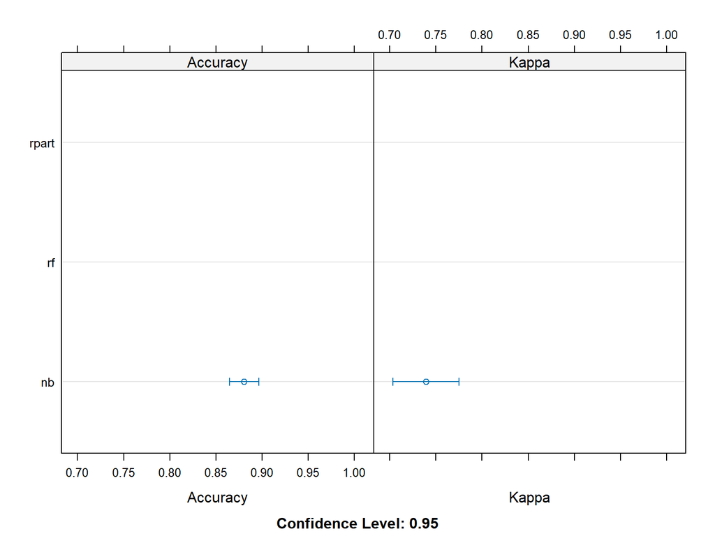

```r
dotplot(results)
```

# Check None of the Models are Highly Correlated

```r
modelCor(results)
```

```
##       rpart rf nb
## rpart     1 NA NA
## rf       NA  1 NA
## nb       NA NA  1
```

# Ensemble the Models

```r
ensemble <- caretEnsemble(model_list,
                            metric = 'Accuracy',
                            trControl = control)
summary(ensemble)
```

```
## The following models were ensembled: rpart, rf, nb
## They were weighted:
## 26.5661 -53.1321 0 0
## The resulting Accuracy is: 1
## The fit for each individual model on the Accuracy is:
##  method  Accuracy AccuracySD
##   rpart 1.0000000 0.00000000
##      rf 1.0000000 0.00000000
##      nb 0.8804625 0.02205883
```

# Visualize the Ensemble

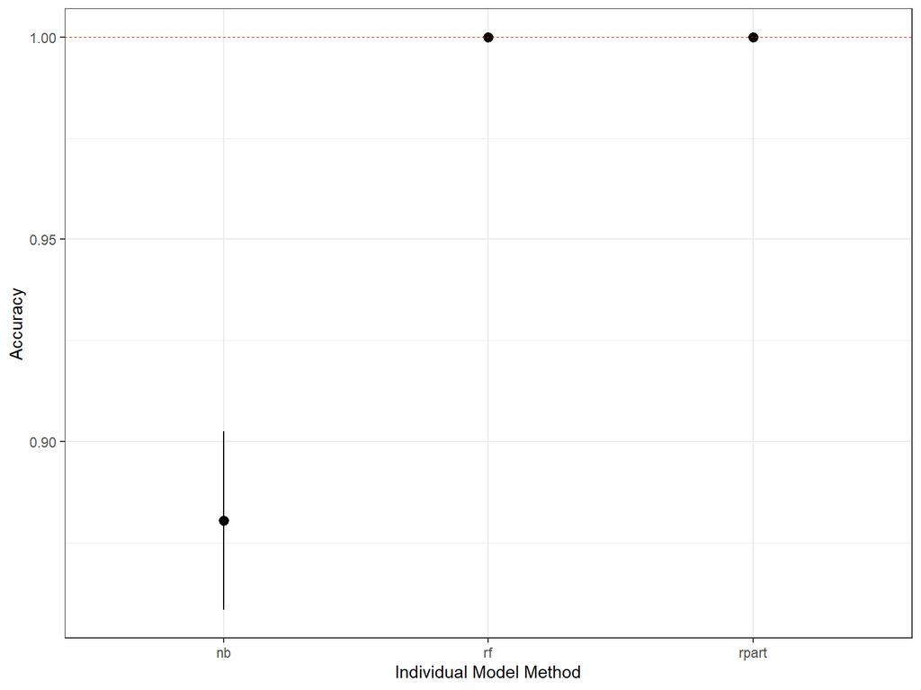

```r
plot(ensemble)
```

# Capture the Prediction

- You may want to grab some other supporting metrics to compare the ensemble performance to the individual models, but will keep it simple now.

```r
data.pred = predict(ensemble, newdata = valid)
cm = confusionMatrix(as.factor(data.pred), reference = as.factor(valid$class))
print(cm)
```

```
## Confusion Matrix and Statistics
##
##           Reference
## Prediction  No Yes
##        No  142   0
##        Yes   0  89
##
##                Accuracy : 1
##                  95% CI : (0.9842, 1)
##     No Information Rate : 0.6147
##     P-Value [Acc > NIR] : < 2.2e-16
##
##                   Kappa : 1
##
##  Mcnemar's Test P-Value : NA
##
##             Sensitivity : 1.0000
##             Specificity : 1.0000
##          Pos Pred Value : 1.0000
##          Neg Pred Value : 1.0000
##              Prevalence : 0.6147
##          Detection Rate : 0.6147
##    Detection Prevalence : 0.6147
##       Balanced Accuracy : 1.0000
##
##        'Positive' Class : No
##
```